# Supervised Learning and Visualisation

Practical 7

Willem van Veluw

24-10-2022

For this practical, we need the following packages. We will also set the seed.

```r
library(MASS)
library(splines)
library(ISLR)
library(tidyverse)
set.seed(45)
```

### Exercise 1

```r
pred_plot <- function(lm){
  x_pred <- data.frame(lstat = seq(min(Boston$lstat), max(Boston$lstat), length.out = 1000))
  preds <- data.frame(lstat = x_pred,
                      medv = predict(lm, newdata = x_pred))

  Boston %>% ggplot(aes(x = lstat, y = medv)) +
     geom_point() +
     geom_line(data = preds, color = "red", size = 1) +
     theme_minimal()
}
```

### Exercise 2

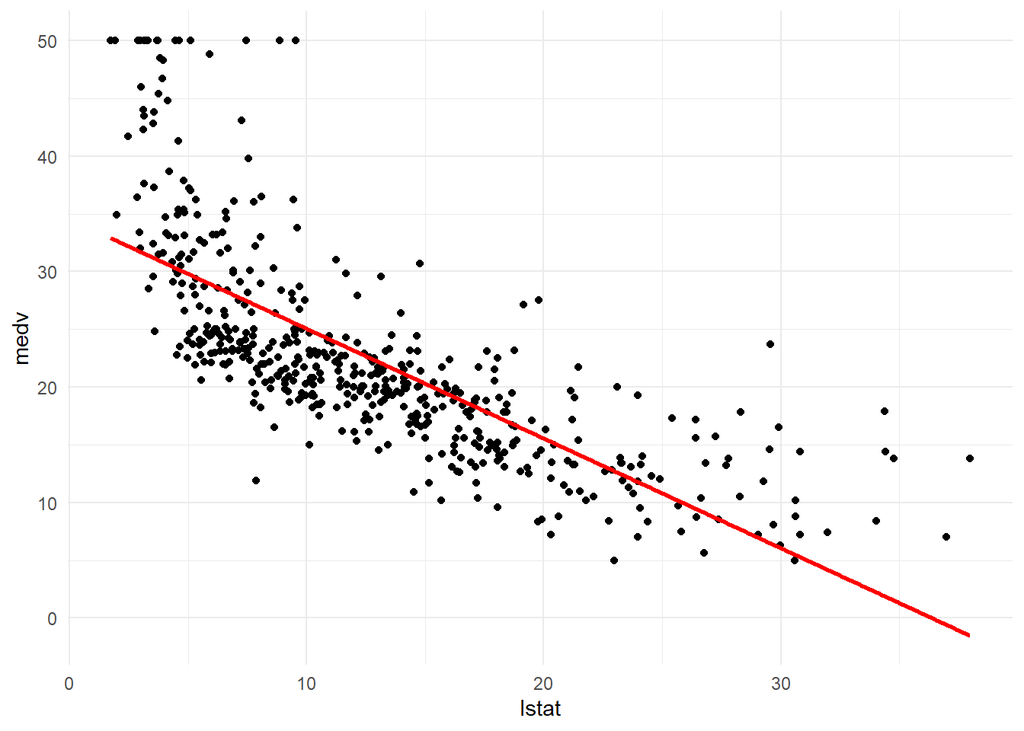

```r
lin_mod <- lm(medv ~ lstat, Boston)
pred_plot(lin_mod)
```

### Exercise 3

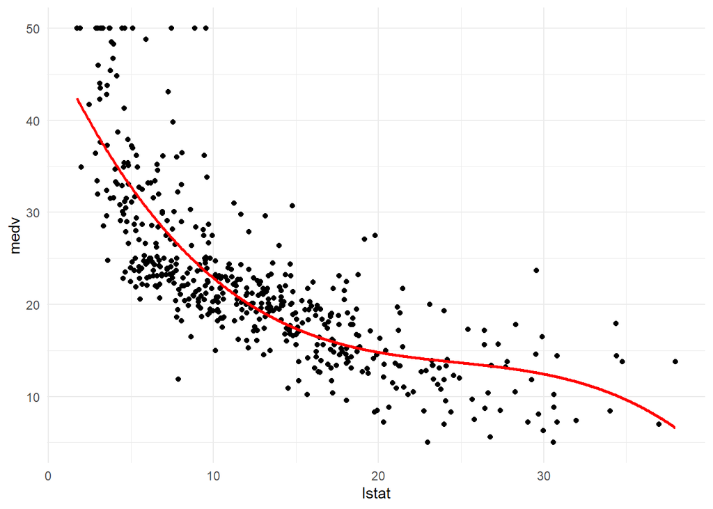

```r
pn3_mod <- lm(medv ~ lstat + I(lstat^2) + I(lstat^3),
              data = Boston)
pred_plot(pn3_mod)
```

### Exercise 4

The function `poly()` needs (at least) a vector with values. Then it substitutes these values in the basis functions of the defined polynomial. If only the vector is fed into `poly()`, it uses a linear “polynomial”.  
With the argument `degree` one can specify the degree of the polynomial. A cubic polynomial is for instance specified by `degree = 3`.  
If the argument `raw` is specified as TRUE, `poly()` returns the raw values, i.e. the specified vector. It then works similar to the identity function.

```r
x <- c(-5:5)
poly(x)
```

```
##                   1
##  [1,] -4.767313e-01
##  [2,] -3.813850e-01
##  [3,] -2.860388e-01
##  [4,] -1.906925e-01
##  [5,] -9.534626e-02
##  [6,]  2.117112e-17
##  [7,]  9.534626e-02
##  [8,]  1.906925e-01
##  [9,]  2.860388e-01
## [10,]  3.813850e-01
## [11,]  4.767313e-01
## attr(,"coefs")
## attr(,"coefs")$alpha
## [1] -8.074349e-17
##
## attr(,"coefs")$norm2
## [1]   1  11 110
##
## attr(,"degree")
## [1] 1
## attr(,"class")
## [1] "poly"   "matrix"
```

```r
poly(x, degree = 3)
```

```
##                   1           2             3
##  [1,] -4.767313e-01  0.51209156 -4.580286e-01
##  [2,] -3.813850e-01  0.20483662  9.160572e-02
##  [3,] -2.860388e-01 -0.03413944  3.358876e-01
##  [4,] -1.906925e-01 -0.20483662  3.511553e-01
##  [5,] -9.534626e-02 -0.30725493  2.137467e-01
##  [6,]  2.117112e-17 -0.34139437 -9.040247e-17
##  [7,]  9.534626e-02 -0.30725493 -2.137467e-01
##  [8,]  1.906925e-01 -0.20483662 -3.511553e-01
##  [9,]  2.860388e-01 -0.03413944 -3.358876e-01
## [10,]  3.813850e-01  0.20483662 -9.160572e-02
## [11,]  4.767313e-01  0.51209156  4.580286e-01
## attr(,"coefs")
## attr(,"coefs")$alpha
## [1] -8.074349e-17 -4.965725e-16 -2.898484e-17
##
## attr(,"coefs")$norm2
## [1]    1.0   11.0  110.0  858.0 6177.6
##
## attr(,"degree")
## [1] 1 2 3
## attr(,"class")
## [1] "poly"   "matrix"
```

```r
poly(x, raw = TRUE)
```

```
##        1
##  [1,] -5
##  [2,] -4
##  [3,] -3
##  [4,] -2
##  [5,] -1
##  [6,]  0
##  [7,]  1
##  [8,]  2
##  [9,]  3
## [10,]  4
## [11,]  5
## attr(,"degree")
## [1] 1
## attr(,"class")
## [1] "poly"   "matrix"
```

### Exercise 5

There is not much of a difference in the prediction between the model of exercise 3 and this model. Both produce equivalent prediction lines.

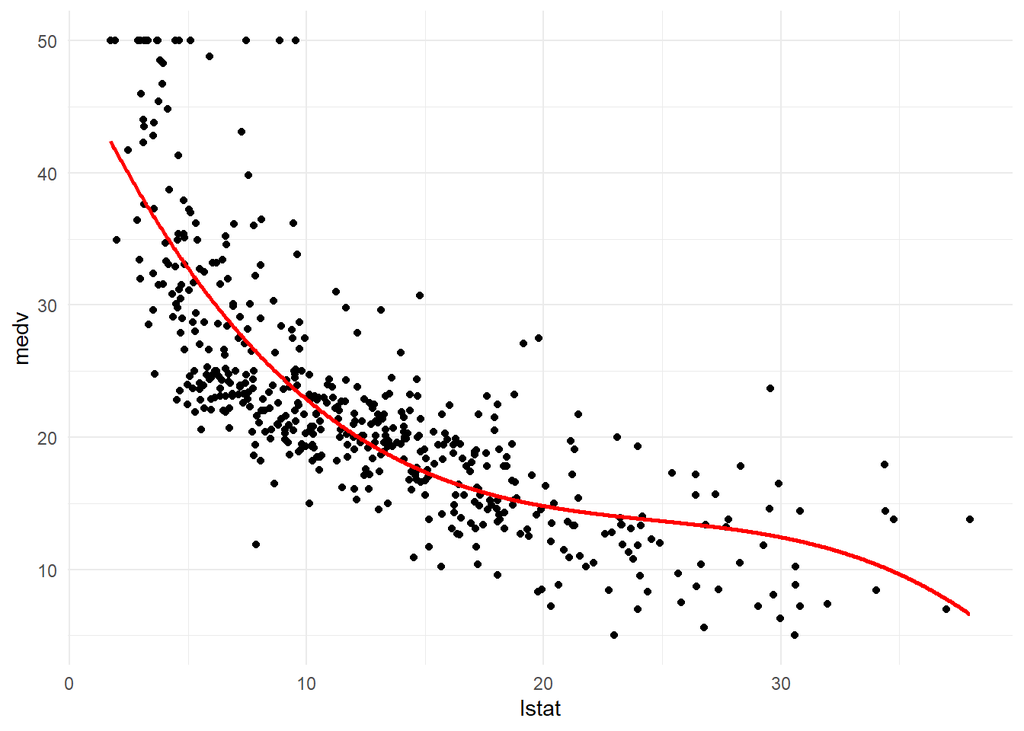

```r
pn3_poly <- lm(medv ~ poly(lstat, degree = 3, raw = TRUE), Boston)
pred_plot(pn3_poly)
```

### Exercise 6

The median value of `lstat` equals 11.36. Hence, the regression formula of `pw2_mod` is $medv = \beta_0 +\beta_1\cdot I_{\{lstat \leq 11.36\}}$, where $I_{\{...\}}$ is an indicator function. The fitted model returns the function
$$medv = 16.677 + 11.711\cdot I_{\{lstat \leq 11.36\}}.$$
Now, a low-lstat neighbourhood typically has a lstat-value less that 11.36. Therefore, the indicator equals 1 and the prediction will be $medv = 16.677 + 11.711\cdot 1 = 28.388$.

[figure not shown]

```r
pw2_mod <- lm(medv ~ I(lstat <= median(lstat)), Boston)
pred_plot(pw2_mod)
```

```r
coef(pw2_mod)
```

```
##                   (Intercept) I(lstat <= median(lstat))TRUE
##                      16.67747                      11.71067
```

### Exercise 7

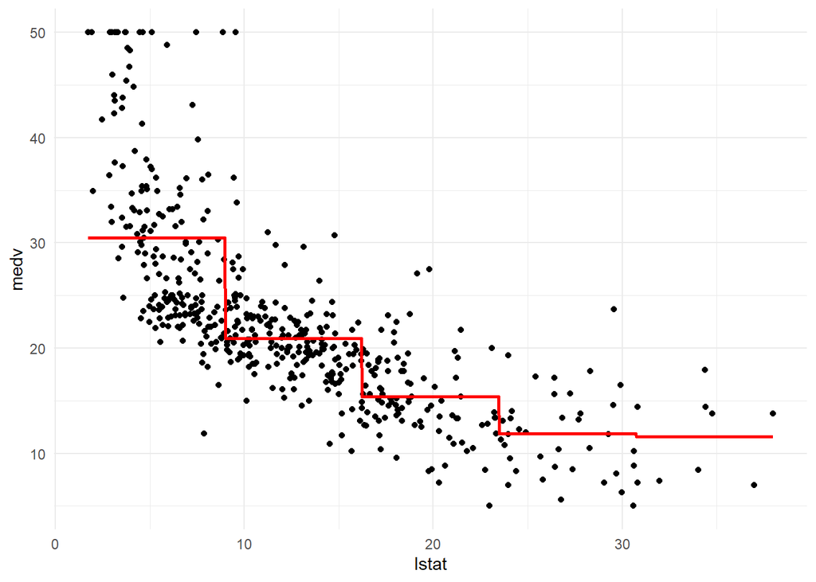

```r
pw5_mod <- lm(medv ~ cut(lstat, 5), Boston)
pred_plot(pw5_mod)
```

### Exercise 8

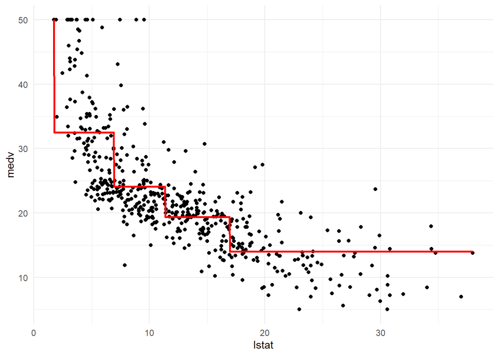

```r
breaks <- c(-Inf, quantile(Boston$lstat), Inf)
pwq_mod <- lm(medv ~ cut(lstat, breaks = breaks),
              data = Boston)
pred_plot(pwq_mod)
```

### Exercise 9

```r
piecewise_cubic_basis <- function(vec, knots = 1) {
  if (knots == 0) return(poly(vec, degree = 3, raw = TRUE))   # If there are no knots, do not split the domain and return a polynomial of degree 3

  cut_vec <- cut(vec, breaks = knots + 1)                     # If the number of knots is specified, cut up the domain according to the knots.
                                                              # We have now divided the domain into __knots__ parts.
  out <- matrix(nrow = length(vec), ncol = 0)                 # Initialise the resulting matrix

  for (lvl in levels(cut_vec)) {                              # For every part of the domain, do
    tmp <- vec
    tmp[cut_vec != lvl] <- 0                                  # Collect the datapoints in the part
    out <- cbind(out, poly(tmp, degree = 3, raw = TRUE))      # Based on these datapoints compute a polynomial of degree 3
  }

  out
}
```

### Exercise 10

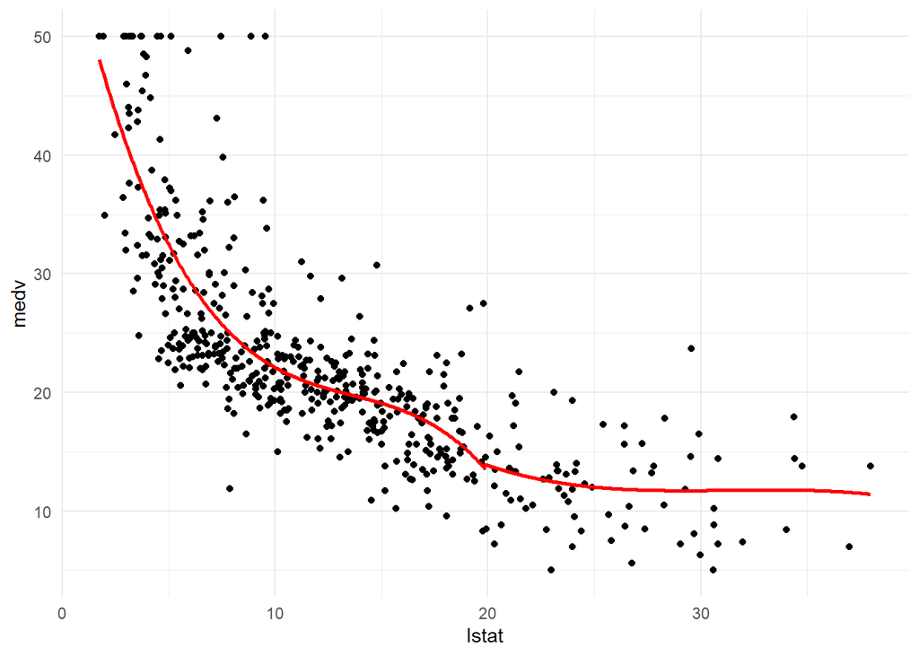

```r
pc1_mod <- lm(medv ~ piecewise_cubic_basis(lstat, knots = 1), Boston)
pred_plot(pc1_mod)
```

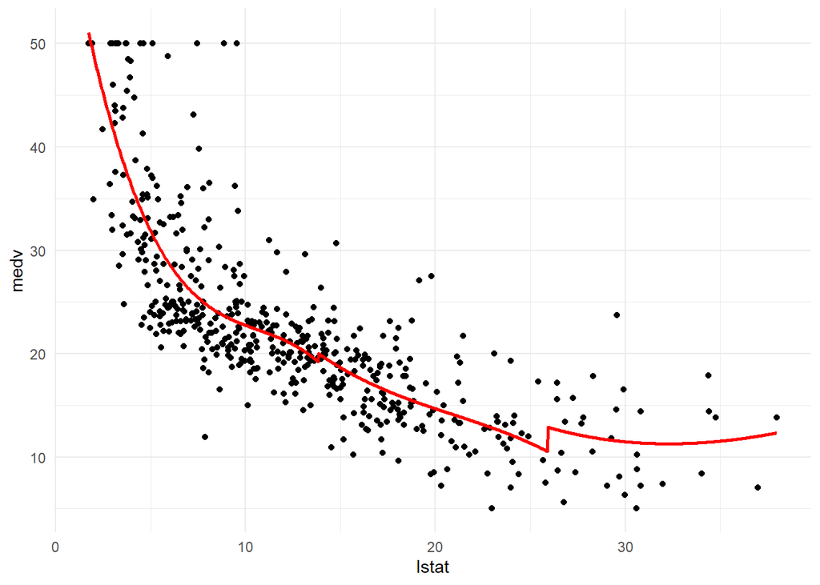

```r
pc2_mod <- lm(medv ~ piecewise_cubic_basis(lstat, knots = 2), Boston)
pred_plot(pc2_mod)
```

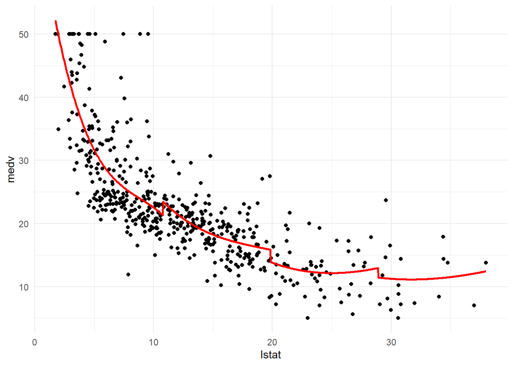

```r
pc3_mod <- lm(medv ~ piecewise_cubic_basis(lstat, knots = 3), Boston)
pred_plot(pc3_mod)
```

### Exercise 11

```r
boston_tpb <- Boston %>% select(medv, lstat)
```

### Exercise 12

```r
boston_tpb <- boston_tpb %>% mutate(lstat2 = lstat^2,
                                    lstat3 = lstat^3)
```

### Exercise 13

```r
val <- (Boston$lstat - median(Boston$lstat))^3
boston_tpb <- boston_tpb %>%
  mutate(lstat_tpb = ifelse(lstat <= median(lstat), val, 0))
```

### Exercise 14

There are four predictors in the model and it has 501 degrees of freedom.

```r
tpb_mod <- lm(medv ~ ., boston_tpb)
```

### Exercise 15

The models have equivalent error on the training set. Hence, we can consider the models to be equivalent.

```r
bs1_mod <- lm(medv ~ bs(lstat, knots = median(lstat)), data = Boston)
mse_tpb <- sum((Boston$medv - predict(tpb_mod))^2)/nrow(Boston)
mse_bs1 <- sum((Boston$medv - predict(bs1_mod))^2)/nrow(Boston)

mse_tpb
```

```
## [1] 26.82969
```

```r
mse_bs1
```

```
## [1] 26.82969
```

### Exercise 16

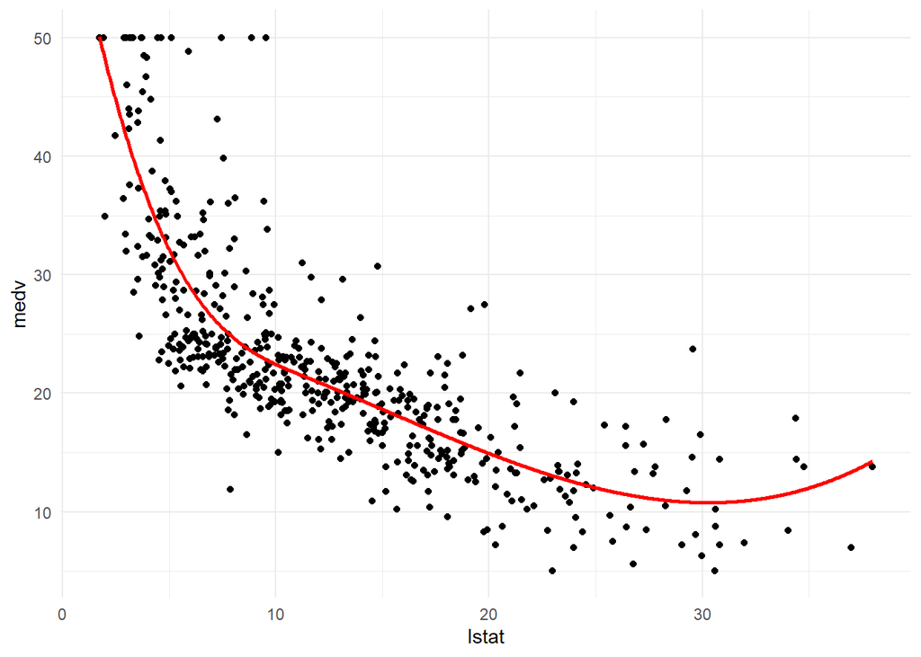

```r
pred_plot(bs1_mod)
```

### Exercise 17

We see different behaviour at the boundaries of the data. The natural spline behaves linearly, whereas the B-spline does not. Thus, we see the requirement of linearity reflected in the prediction plots.

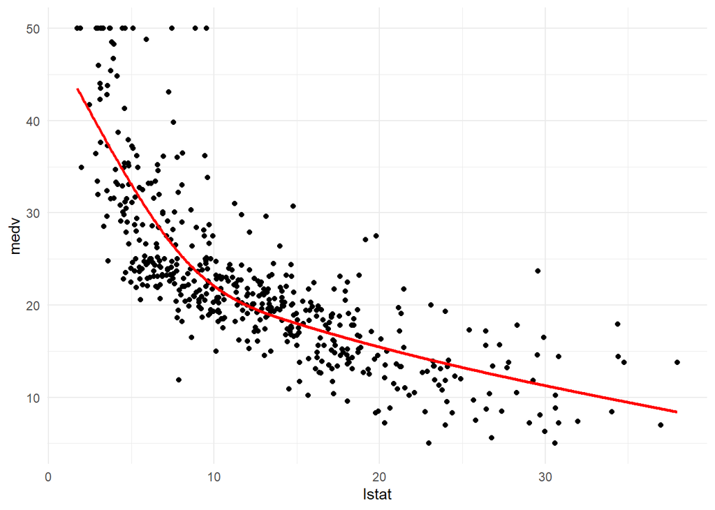

```r
ns3_mod <- lm(medv ~ ns(lstat, df = 3), Boston)
pred_plot(ns3_mod)
```

### Exercise 18

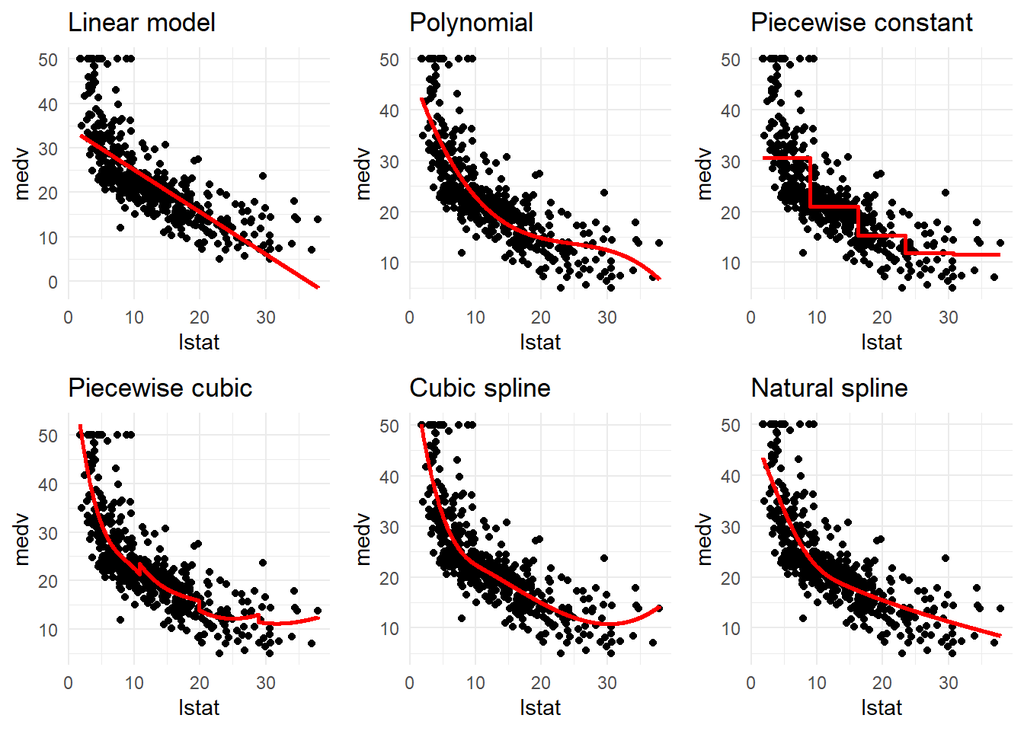

```r
library(cowplot)
p1 <- pred_plot(lin_mod) + ggtitle("Linear model")
p2 <- pred_plot(pn3_mod) + ggtitle("Polynomial")
p3 <- pred_plot(pw5_mod) + ggtitle("Piecewise constant")
p4 <- pred_plot(pc3_mod) + ggtitle("Piecewise cubic")
p5 <- pred_plot(bs1_mod) + ggtitle("Cubic spline ")
p6 <- pred_plot(ns3_mod) + ggtitle("Natural spline")

cowplot::plot_grid(p1,p2,p3,p4,p5,p6)
```

### Exercise 19

First we create the dataset and split it into twelve folds.

```r
fold_break <- floor(nrow(Boston)/12)
fold <- c()
for(i in 1:11){
  fold <- c(fold, rep(i, fold_break))
}
fold <- c(fold, rep(12, nrow(Boston) - length(fold)))
data <- Boston %>% select(medv, lstat) %>% mutate(fold = sample(fold))
head(data)
```

|  | medv | lstat | fold |
| --- | --- | --- | --- |
| 1 | 24.0 | 4.98 | 1 |
| 2 | 21.6 | 9.14 | 8 |
| 3 | 34.7 | 4.03 | 11 |
| 4 | 33.4 | 2.94 | 6 |
| 5 | 36.2 | 5.33 | 1 |
| 6 | 28.7 | 5.21 | 2 |

We also need a function that computes the MSE.

```r
mse <- function(trues, preds){
  return( sum((trues - preds)^2)/length(trues))
}
```

Now we can train every model on the folds, compute its MSE and average the MSE over all folds.

```r
lin_mses <- c()
for(i in 1:12){
  train <- data %>% filter(fold != i)
  test <- data %>% filter(fold == i)
  model <- lm(medv ~ lstat, data = train)
  preds <- predict(model, newdata = test)
  lin_mses <- c(lin_mses, mse(test$medv, preds))
}

pn3_mses <- c()
for(i in 1:12){
  train <- data %>% filter(fold != i)
  test <- data %>% filter(fold == i)
  model <- lm(medv ~ lstat + I(lstat^2) + I(lstat^3), data = train)
  preds <- predict(model, newdata = test)
  pn3_mses <- c(pn3_mses, mse(test$medv, preds))
}

pw5_mses <- c()
breaks <- c(-Inf, 7, 15, 22, Inf)
for(i in 1:12){
  train <- data %>% filter(fold != i)
  test <- data %>% filter(fold == i)
  model <- lm(medv ~ cut(lstat, breaks), data = train)
  preds <- predict(model, newdata = test)
  pw5_mses <- c(pw5_mses, mse(test$medv, preds))
}

pc3_mses <- c()
for(i in 1:12){
  train <- data %>% filter(fold != i)
  test <- data %>% filter(fold == i)
  model <- lm(medv ~ piecewise_cubic_basis(lstat, knots = 3), data = train)
  preds <- predict(model, newdata = test)
  pc3_mses <- c(pc3_mses, mse(test$medv, preds))
}

bs1_mses <- c()
for(i in 1:12){
  train <- data %>% filter(fold != i)
  test <- data %>% filter(fold == i)
  model <- lm(medv ~ bs(lstat, knots = median(lstat)), data = train)
  preds <- predict(model, newdata = test)
  bs1_mses <- c(bs1_mses, mse(test$medv, preds))
}

ns3_mses <- c()
for(i in 1:12){
  train <- data %>% filter(fold != i)
  test <- data %>% filter(fold == i)
  model <- lm(medv ~ ns(lstat, df = 3), data = train)
  preds <- predict(model, newdata = test)
  ns3_mses <- c(ns3_mses, mse(test$medv, preds))
}
```

The results of the cross validation is shown below. Since we want to minimise the MSE, we conclude that the Cubic Spline fits the best.

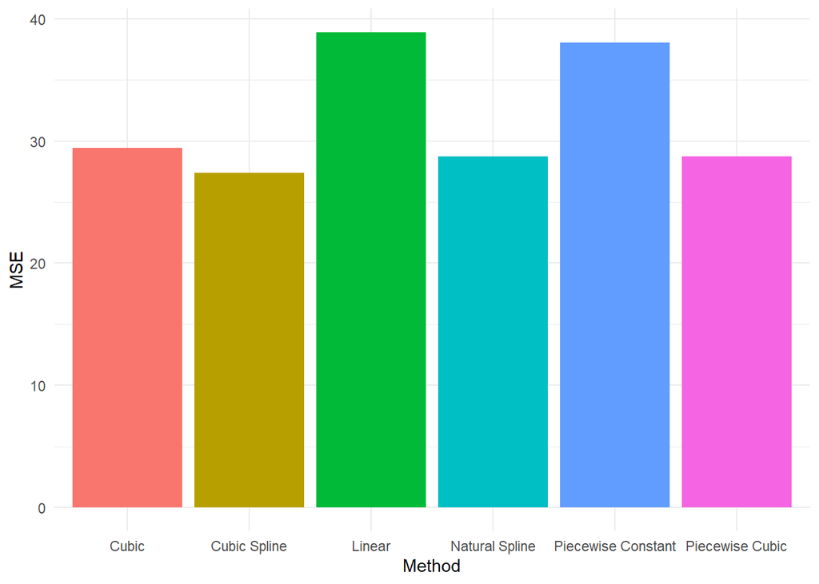

```r
cv12 <- data.frame(MSE = c(mean(lin_mses), mean(pn3_mses), mean(pw5_mses),
                           mean(pc3_mses), mean(bs1_mses), mean(ns3_mses)),
                   Method = c("Linear", "Cubic", "Piecewise Constant",
                              "Piecewise Cubic", "Cubic Spline", "Natural Spline"))

cv12 %>% ggplot(aes(x = Method, y = MSE, fill = Method)) +
  geom_bar(stat = "identity", show.legend = FALSE) +
  theme_minimal()
```